# Protein Aptamer Deconvolution Simulation

Alex Abbas

2024-05-19

# Introduction

# Data

## Proteins

Human proteins from the Protein Atlas known to be secreted to blood:

```r
hpa = read.csv("data/proteinatlas.csv")
hpa = hpa %>% dplyr::select(Gene, Ensembl, Gene.description, Uniprot, Secretome.location)
hpa = hpa %>% mutate(SecretedBlood = Secretome.location == "Secreted to blood")
secretome = hpa %>% dplyr::filter(SecretedBlood) %>% dplyr::select(-Secretome.location,-SecretedBlood)

# build secretome library and aptamer library
edb <- EnsDb.Hsapiens.v86
prts1 <- proteins(edb, filter = GeneNameFilter(secretome$Gene), columns = c("gene_id","protein_sequence")) %>% data.frame
prts = prts1 %>% group_by(gene_name) %>% dplyr::slice(1)
meanConc = read.csv("data/meanConc.txt",sep="\t",header=F) # from
colnames(meanConc) = c("gene_name","description","X40.g.L.1","x")
meanConc = meanConc %>% dplyr::select(-x)
meanConc <- meanConc %>% separate(X40.g.L.1, c('MeanConc', 'MeanUnit'), sep = " ") %>% mutate(MeanConc = as.numeric(MeanConc))
multHash = c(
  "g/L" = 1e9,
  "mg/L" = 1e6,
  "µg/L" = 1e3,
  "ng/L" = 1
)
meanConc = meanConc %>% mutate(MeanVal = MeanConc * multHash[MeanUnit])
prts = inner_join(prts,meanConc)
datatable(prts %>% dplyr::select(-protein_sequence, -MeanVal))
```

|  | gene_id | protein_id | gene_name | description | MeanConc | MeanUnit |
| --- | --- | --- | --- | --- | --- | --- |
| 1 | ENSG00000121410 | ENSP00000263100 | A1BG | Alpha-1-B glycoprotein | 200 | mg/L |
| 2 | ENSG00000175899 | ENSP00000323929 | A2M | Alpha-2-macroglobulin | 1.6 | g/L |
| 3 | ENSG00000159640 | ENSP00000462995 | ACE | Angiotensin I converting enzyme | 100 | µg/L |
| 4 | ENSG00000130234 | ENSP00000252519 | ACE2 | Angiotensin converting enzyme 2 | 4.5 | µg/L |
| 5 | ENSG00000160323 | ENSP00000360997 | ADAMTS13 | ADAM metallopeptidase with thrombospondin type 1 motif 13 | 1.3 | mg/L |
| 6 | ENSG00000123146 | ENSP00000351413 | ADGRE5 | Adhesion G protein-coupled receptor E5 | 10 | µg/L |
| 7 | ENSG00000181092 | ENSP00000320709 | ADIPOQ | Adiponectin, C1Q and collagen domain containing | 8.4 | mg/L |
| 8 | ENSG00000148926 | ENSP00000278175 | ADM | Adrenomedullin | 31 | ng/L |
| 9 | ENSG00000128165 | ENSP00000379087 | ADM2 | Adrenomedullin 2 | 61 | ng/L |
| 10 | ENSG00000079557 | ENSP00000226355 | AFM | Afamin | 55 | mg/L |

[output cut: 387 more lines]

## Aptamers

```r
# set  parameters
onTargetAffinity = 1e-5
offTargetAffinity = 1e-1
conc = 1e-3
pctAptamerCoverage = 0.1
affinityStdDev = 0.6

get_kmers <- function(string, k=3) {
  if (k > nchar(string)) { stop("k cannot be greater than the length of the string") } # Check if k is greater than the length of the string
  kmers <- character(0) # Initialize an empty vector to store the kmers
  for (i in 1:(nchar(string) - k + 1)) { # Loop through the string to extract kmers
    kmer <- substr(string, i, i + k - 1)
    kmers <- c(kmers, kmer)
  }
  kmers
}

trimers = sapply(prts$protein_sequence, get_kmers) %>% unlist %>% unique
aptamers = sample(trimers, size = floor(length(trimers)/2))
onTargetAffinities = rnorm(length(aptamers), mean = log10(onTargetAffinity), sd = affinityStdDev)
names(onTargetAffinities) = aptamers
offTargetAffinities = rnorm(length(aptamers), mean = log10(offTargetAffinity), sd = affinityStdDev)
names(offTargetAffinities) = aptamers
```

3949 aptamers are made.

Plot the distribution of observed aptamer affinities for all tripeptides. The large peak is low affinity non-specific binding, and the small peak around -6 is the high affinity on-target binding.

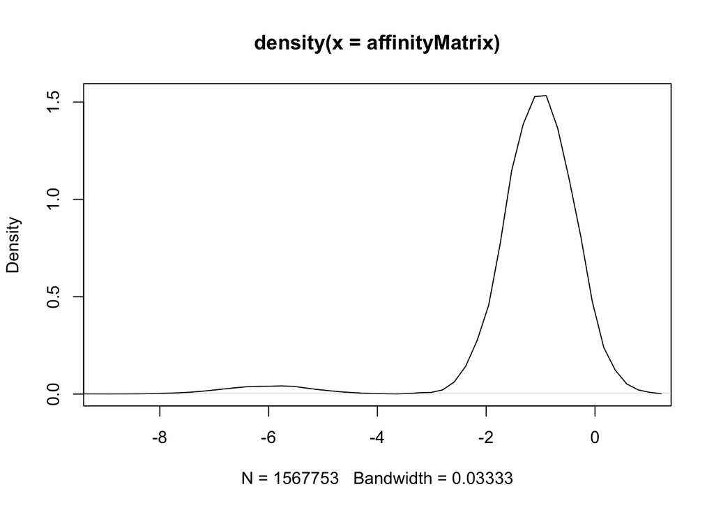

```r
affinityMatrix = do.call(cbind,lapply(prts$protein_sequence, function(aseq) {
  aseq_trimer_table = table(get_kmers(aseq))
  aseq_trimer_apt = aseq_trimer_table[names(aseq_trimer_table) %in% aptamers]
  aseq_trimer_apt[setdiff(aptamers,names(aseq_trimer_apt))] = 0
  all_aptamers_counts = aseq_trimer_apt[aptamers]
  affinities = offTargetAffinities + onTargetAffinities * all_aptamers_counts
  affinities
}))
colnames(affinityMatrix) = prts$gene_name
probMatrix = 1 / (1 + exp(1) ^ (affinityMatrix - log10(conc)))
plot(density(affinityMatrix),xlim=c(-9,1))
```

## Probability fit

Let’s fit a two-group gaussian mixed model to the binding probabilities.

```r
dataToFit = sample(unlist(probMatrix),1e3)
fit = Mclust(dataToFit, G=2, model="V")
summary(fit)
```

```
----------------------------------------------------
Gaussian finite mixture model fitted by EM algorithm
----------------------------------------------------

Mclust V (univariate, unequal variance) model with 2 components:

 log-likelihood    n df      BIC      ICL
       1062.198 1000  5 2089.858 2052.325

Clustering table:
  1   2
945  55
```

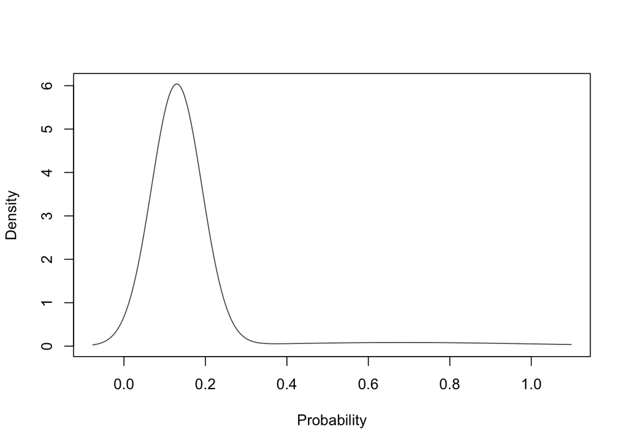

```r
plot(fit, what="density", xlab = "Probability")
```

## Make test sample

Now let’s create one test sample of 100 proteins on 100 tiles (100% occupancy!), with proteins selected at random according to typical normal healthy blood serum protein relative abundances. Mostly albumin!

```r
numOfSpots = 1e2
testProteins = sample(prts$gene_name, size = numOfSpots, prob = prts$MeanVal / max(prts$MeanVal), replace = T)
aptamerHits = do.call(cbind, lapply(testProteins, function(testProtein) {
  sapply(aptamers, function(aptamer) {
    p = probMatrix[aptamer,testProtein]
    sample(c(1,0), 1, prob = c(p,1-p))
  })
}))
table(testProteins)
```

```
testProteins
     A2M     AHSG      ALB    APOA1     APOB       C3    C4BPB       CP
       2        1       51        5        5        2        1        2
   GPLD1 SERPINA1 SERPINA3       TF      VTN
       1        2        1       26        1
```

## Assess test sample

Finally, let’s run our virtual assay and empirically identify the proteins by the discrete values of aptamers that bound or did not bind to each protein, by computing a joint probability of each observed aptamer binding event for each possible protein identity. The raw score is just the pearson correlation of the observed aptamer binding states and the aptamer binding probabilities of the top match. The marginal p-value is the log10 difference between the probability of the top hit and the probability of the second place hit (so, the higher the better).

```r
cors = cor(aptamerHits, probMatrix)
testResults = bind_rows(lapply(c(1:100),function(test_i){
  aCors = cors[test_i,]
  maxCor = max(aCors)
  secondCor = sort(aCors,decreasing = T)[2]
  fit = fitdistr(aCors, "normal")
  para = fit$estimate
  p1 = pnorm(maxCor, mean = para["mean"], sd = para["sd"], lower.tail=F)
  p2 = pnorm(secondCor, mean = para["mean"], sd = para["sd"], lower.tail=F)
  names(p2) = NULL
  assignment = prts$gene_name[aCors==maxCor]
  c("True_protein" = testProteins[test_i], "Inferred_protein" = assignment, "Score" = maxCor, "Marginal_Pval" = -log10(p1) + log10(p2))
}))

datatable(testResults)
```

|  | True_protein | Inferred_protein | Score | Marginal_Pval |
| --- | --- | --- | --- | --- |
| 1 | TF | TF | 0.577099758733701 | 42.1042962634815 |
| 2 | TF | TF | 0.589409301376329 | 42.0292943488068 |
| 3 | TF | TF | 0.610257242340182 | 48.4909955996541 |
| 4 | ALB | ALB | 0.413577744019702 | 19.1500192165359 |
| 5 | C3 | C3 | 0.712600418141628 | 65.6642878702281 |
| 6 | GPLD1 | GPLD1 | 0.604343036904017 | 50.570214817403 |
| 7 | TF | TF | 0.585906688171301 | 39.0542804591205 |
| 8 | ALB | ALB | 0.415385952056045 | 15.6363892912116 |
| 9 | ALB | ALB | 0.391453890484986 | 17.7209865377628 |
| 10 | TF | TF | 0.561480620991315 | 42.5628736300985 |

[output cut: 90 more lines]

And a confusion table of the results.

```r
confusion = confusionMatrix(data = factor(testResults$Inferred_protein), reference = factor(testResults$True_protein))
confusion
```

```
Confusion Matrix and Statistics

          Reference
Prediction A2M AHSG ALB APOA1 APOB C3 C4BPB CP GPLD1 SERPINA1 SERPINA3 TF VTN
  A2M        2    0   0     0    0  0     0  0     0        0        0  0   0
  AHSG       0    1   0     0    0  0     0  0     0        0        0  0   0
  ALB        0    0  51     0    0  0     0  0     0        0        0  0   0
  APOA1      0    0   0     5    0  0     0  0     0        0        0  0   0
  APOB       0    0   0     0    5  0     0  0     0        0        0  0   0
  C3         0    0   0     0    0  2     0  0     0        0        0  0   0
  C4BPB      0    0   0     0    0  0     1  0     0        0        0  0   0
  CP         0    0   0     0    0  0     0  2     0        0        0  0   0
  GPLD1      0    0   0     0    0  0     0  0     1        0        0  0   0
  SERPINA1   0    0   0     0    0  0     0  0     0        2        0  0   0
  SERPINA3   0    0   0     0    0  0     0  0     0        0        1  0   0
  TF         0    0   0     0    0  0     0  0     0        0        0 26   0
  VTN        0    0   0     0    0  0     0  0     0        0        0  0   1

Overall Statistics

               Accuracy : 1
                 95% CI : (0.9638, 1)
    No Information Rate : 0.51
    P-Value [Acc > NIR] : < 2.2e-16

                  Kappa : 1

 Mcnemar's Test P-Value : NA

Statistics by Class:

                     Class: A2M Class: AHSG Class: ALB Class: APOA1 Class: APOB
Sensitivity                1.00        1.00       1.00         1.00        1.00
Specificity                1.00        1.00       1.00         1.00        1.00
Pos Pred Value             1.00        1.00       1.00         1.00        1.00
Neg Pred Value             1.00        1.00       1.00         1.00        1.00
Prevalence                 0.02        0.01       0.51         0.05        0.05
Detection Rate             0.02        0.01       0.51         0.05        0.05
Detection Prevalence       0.02        0.01       0.51         0.05        0.05
Balanced Accuracy          1.00        1.00       1.00         1.00        1.00
                     Class: C3 Class: C4BPB Class: CP Class: GPLD1
Sensitivity               1.00         1.00      1.00         1.00
Specificity               1.00         1.00      1.00         1.00
Pos Pred Value            1.00         1.00      1.00         1.00
Neg Pred Value            1.00         1.00      1.00         1.00
Prevalence                0.02         0.01      0.02         0.01
Detection Rate            0.02         0.01      0.02         0.01
Detection Prevalence      0.02         0.01      0.02         0.01
Balanced Accuracy         1.00         1.00      1.00         1.00
                     Class: SERPINA1 Class: SERPINA3 Class: TF Class: VTN
Sensitivity                     1.00            1.00      1.00       1.00
Specificity                     1.00            1.00      1.00       1.00
Pos Pred Value                  1.00            1.00      1.00       1.00
Neg Pred Value                  1.00            1.00      1.00       1.00
Prevalence                      0.02            0.01      0.26       0.01
Detection Rate                  0.02            0.01      0.26       0.01
Detection Prevalence            0.02            0.01      0.26       0.01
Balanced Accuracy               1.00            1.00      1.00       1.00
```